# Aircraft Usage & Maintenance Analysis

Author

Will Schneider

# Large-cabin Business Jet

**Executive summary**

## Variable Analysis

### Maintenance

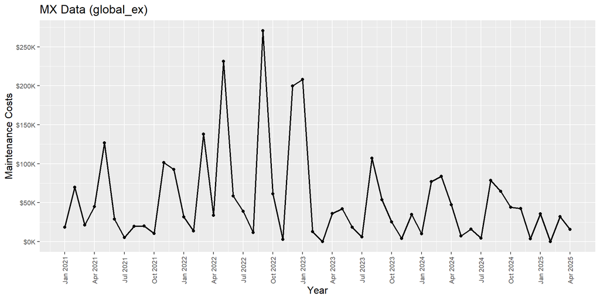

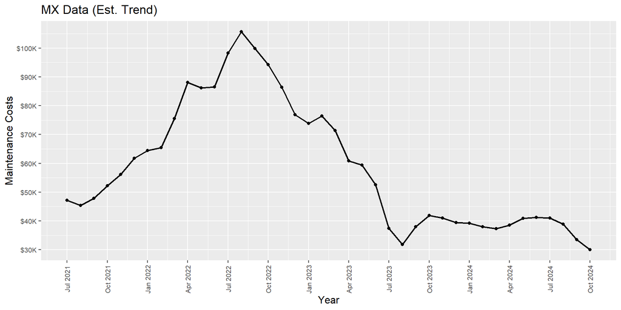

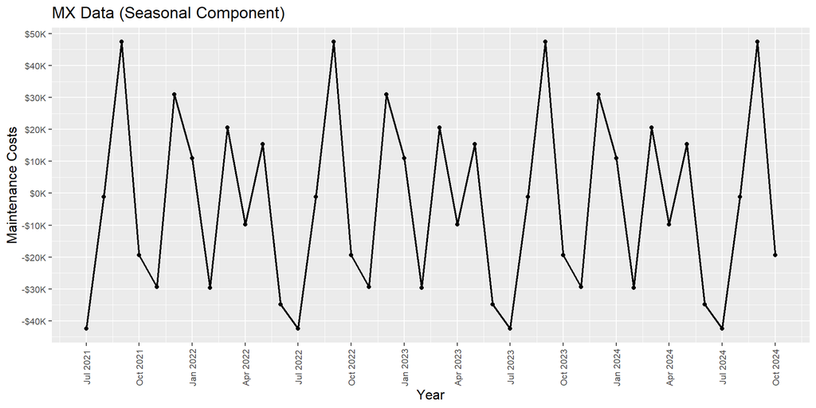

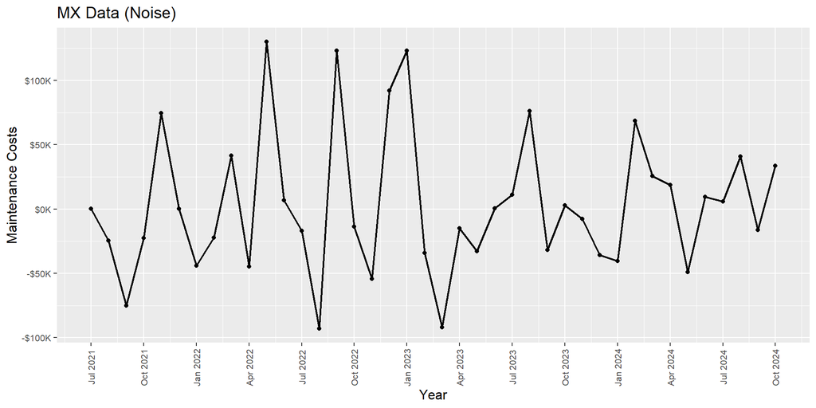

| Trend | Seasonality/Cycle | Near-term persistence |
| --- | --- | --- |
| flat | present (quarterly) | yes |

#### Interpretation of Time Series Components

Monthly costs show short‑term reversals and a recurring cycle about every 4 months, matching the ACF and spectrum.

**Trend:** Shows the general, long-term direction of maintenance costs over time. It helps us understand whether costs are generally rising, falling, or remaining stable.

**Seasonal:**Reflects predictable fluctuations within each year. Positive values indicate months when costs typically exceed the overall trend, and negative values indicate months when costs are typically below trend.

**Noise:** Represents unpredictable, irregular variations in maintenance costs. This is the **leftover variation** once the trend and seasonal patterns are accounted for.

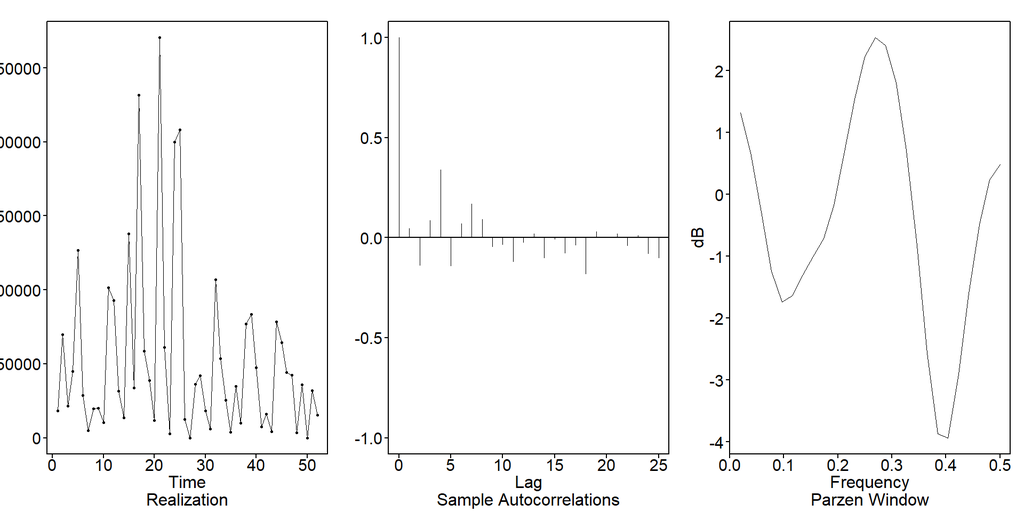

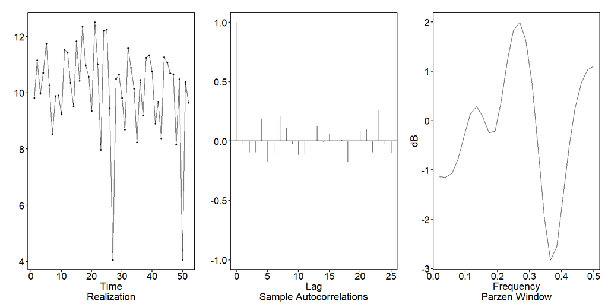

#### Interpretation of Sample Autocorrelations & Spectral Density

**Realization (left plot):**

Monthly maintenance costs vary substantially month-to-month, with no consistent long-term upward or downward trend visible.

**Takeaway:** plan for short bursts and pullbacks rather than a smooth trend.

**Autocorrelations (middle plot):**

Autocorrelation measures how closely each month’s costs depend on previous months. Costs exhibit moderate predictability every 3-4 months—high-cost months tend to be followed by lower-cost months several periods later, showing short-term reversals.

**Takeaway:** near‑term scheduling and staffing can be adjusted on a 1–4 month horizon; beyond that, past values carry little signal.

**Spectral Density:**

Spectral density identifies how strongly certain cycles repeat throughout the entire data set. Analysis reveals a robust quarterly pattern, confirming costs consistently cycle every 4 months ($1/f = 1/0.25 = 4$). This aligns directly with month-to-month observations from autocorrelation.

**Takeaway:** expect recurring cost waves roughly every quarter; align inspections and spares accordingly.

In short, maintenance costs demonstrate clear quarterly cyclicality, with costs alternating regularly, and this recurring pattern persists throughout the historical data.

### Flight Hours

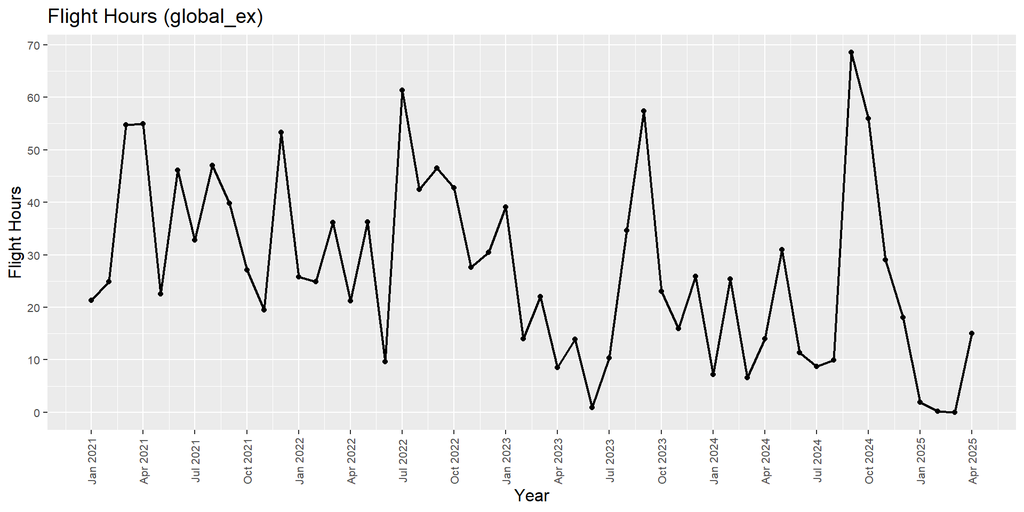

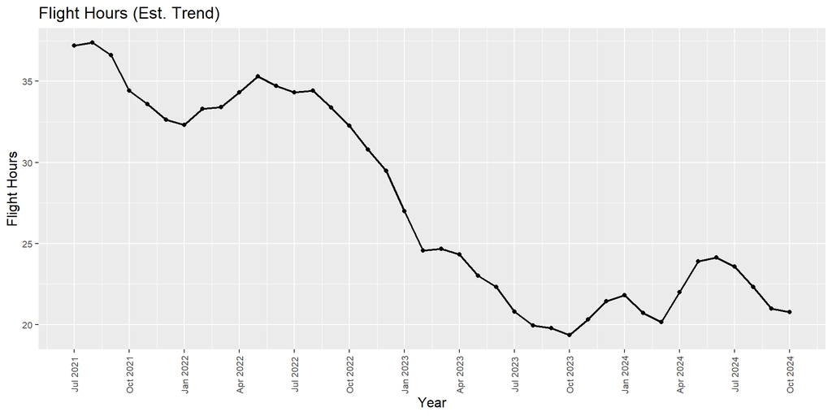

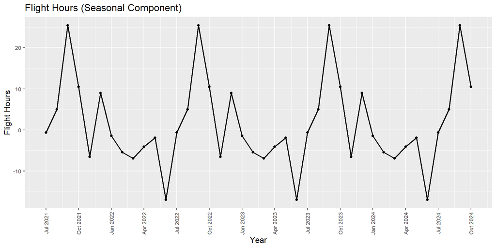

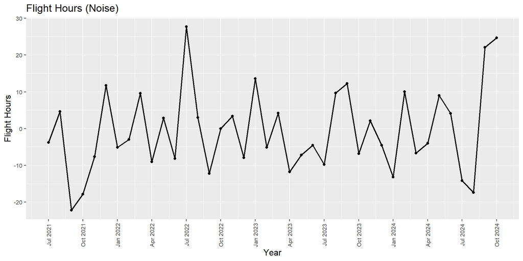

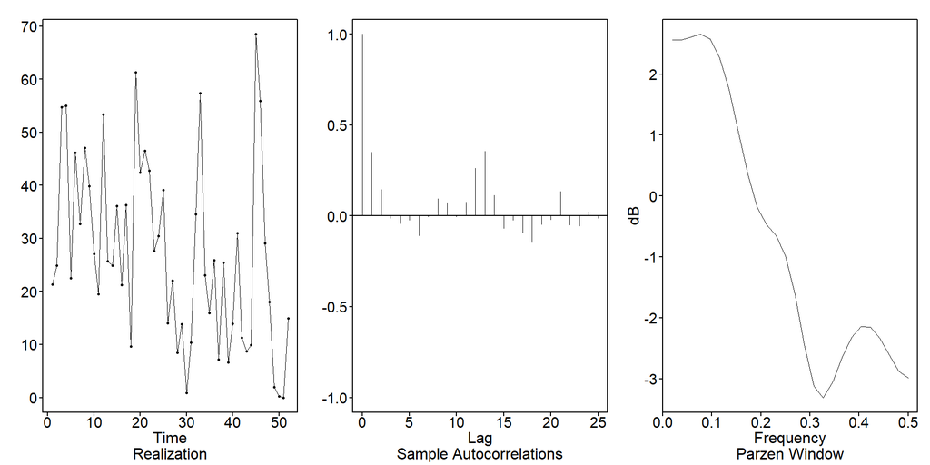

[output not shown]

#### Interpretation of Sample Autocorrelations & Spectral Density

**Takeaway:** past values add limited predictive value beyond the next few months; avoid assuming carryover effects and treat spikes as transient rather than persistent.

**Takeaway:** no durable seasonal cycle; plan hours on observed demand and operations, not on fixed seasonality.

**Bottom line:** use external drivers and operational context for planning; naive extrapolation of monthly hours is weak.

### MX & Flight Hours

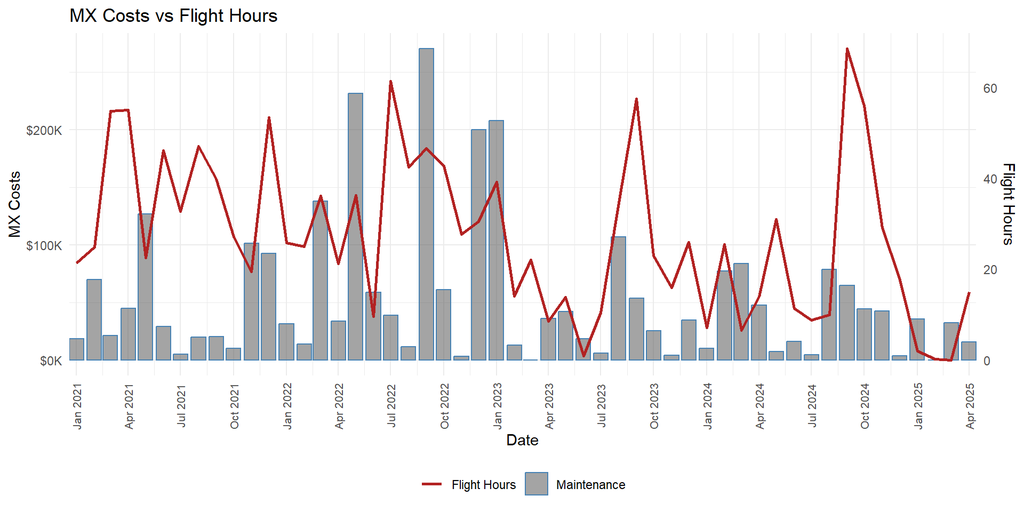

### Seasonality

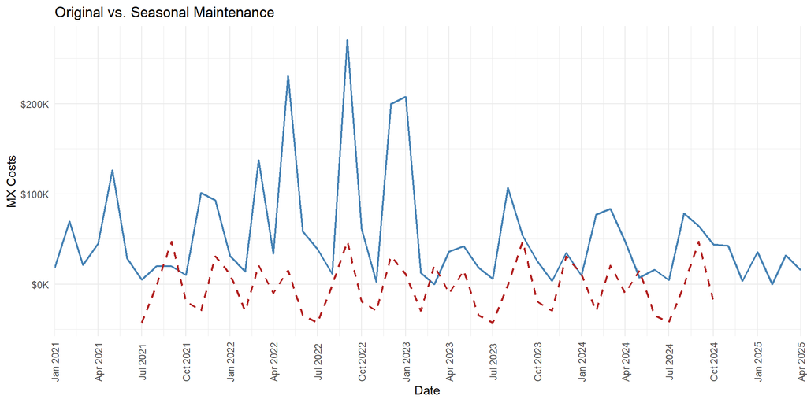

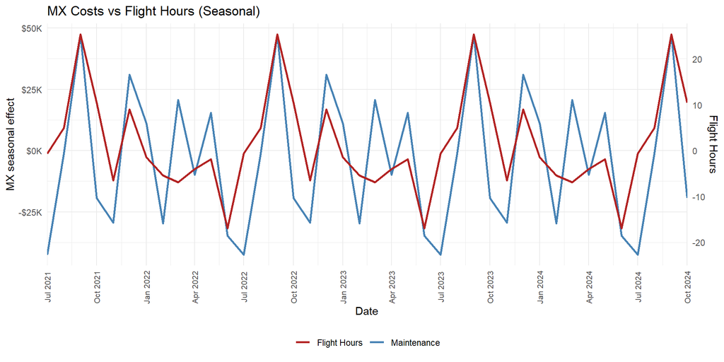

## Vector Autoregression (VAR) Analysis

### Model Selection

**What this does:** Forecasts next-month maintenance and hours together so each can inform the other.

**Why this matters:** Produces consistent month-ahead projections for both series and captures cross-effects without over-relying on any single trend.

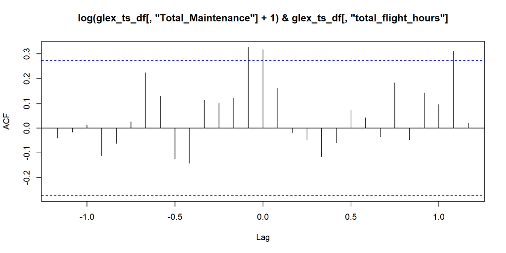

```
[1] "The Logged MX Data is: Stationary (0.05 confidence level)"
```

[output not shown]

```
Obs -0.01917548 -0.1147517 -0.07662087 0.1989264 -0.1594439 -0.0803169 0.2515505 0.0589387 -0.01798786 -0.1112716 -0.07612201 -0.1622957
```

```
[1] 0.3488594
```

```
Obs -0.01917548 -0.1147517 -0.07662087 0.1989264 -0.1594439 -0.0803169 0.2515505 0.0589387 -0.01798786 -0.1112716 -0.07612201 -0.1622957 0.08736132 0.01976597 0.04187523 0.005334024 -0.0179761 -0.1503146 0.07846756 0.08467874 0.05113241 -0.1084868 0.2814894 2.961895e-05
```

```
[1] 0.3579254
```

### Testing

**What this does:** We hold out the last six months, fit the model on earlier data, forecast six steps, and compare forecasts to actuals. All results are returned to original units for a direct, apples-to-apples check of accuracy.

```
[1] 2.703611
```

```
[1] 27183.34
```

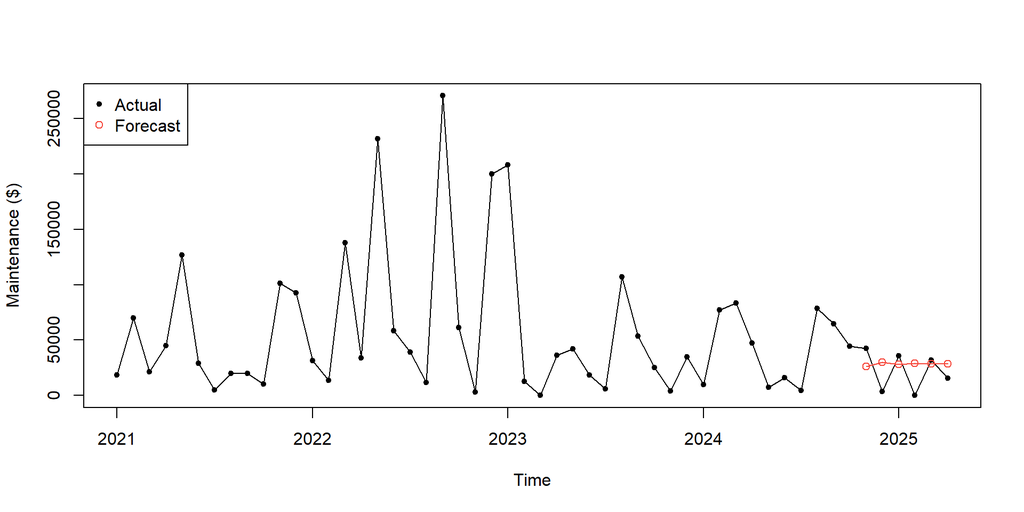

### Deployment

**What this does:** We refit on the full history and generate multi-step forecasts for both series. We publish maintenance on its original scale and include hours as needed for planning and capacity decisions.

*Forecasts are most reliable inside 1–3 months; uncertainty widens beyond that.*

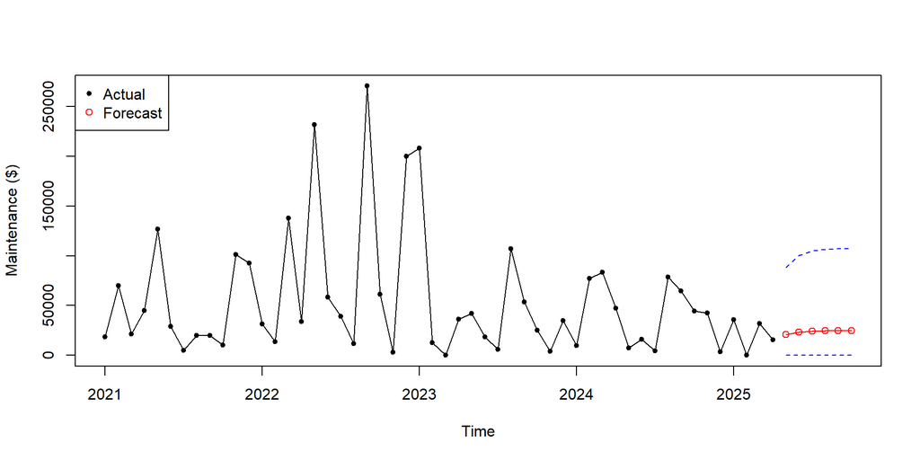

## VARX: Nowcasting Maintenance with Known Same‑Month Flight Hours

### Preface

**Important**

**Bottom line:** When current-month flight hours are known, VARX gives a better same-month maintenance nowcast and keeps multi-month forecasts aligned with operations.

We receive flight hours for month t about two weeks before maintenance costs for month t are finalized. A standard VAR uses only past values and cannot use those known same-month hours. VARX solves this by keeping **maintenance** as the modeled series and adding **flight hours** (current month plus optional lags) as external inputs. This lets us publish a maintenance nowcast for month t as soon as hours for t are available and uses the 0–2 week information lead on hours.

**Why show VARX next to the baseline VAR** - **VAR:** joint model using lags only. Use when current hours are not yet known. - **VARX:** adds known current hours H_t (and recent lags if helpful). Use when hours arrive first and you need a same-month maintenance nowcast.

**Process** This mirrors the baseline VAR workflow with one change: hours are added as external inputs. Stability checks, constant or trend selection, lag order p, diagnostics, backtesting, and deployment remain the same.

### VARX Model Selection (hours as exogenous)

#### Parts & Labor as Additional Endogenous Variables

Because VAR works with at least 2 endogenous variables, and because we are turning Flight Hours into a exogenous variables for the purpose of maintaining more realistic modeling expectations of the flow and delivery sequences of the data, we will include two additional variables in additional to Total Maintenance. These are Parts & Labor, which are sub-costs of Total Maintenance. In addition to improving the functionality of the model, these variables may also prove to explain additional makeup of the analyses and forecasts.

```
Obs 0.02834691 -0.001526177 0.07364602 0.1032121 -0.1031722 -0.0965174 0.1646825 0.02035853 -0.248515 0.0110596 -0.1373718 -0.06401822
Obs -0.1630205 0.07295282 0.04916672 -0.1178231 0.02404812 -0.09276493 0.01421663 0.1914904 -0.09731188 0.1446444 -0.05544164 0.003662337
Obs 0.01116721 -0.03394459 0.145519 0.07380859 -0.05116777 0.1450612 -0.09929817 -0.1090613 -0.2992921 -0.1741096 -0.03825385 -0.1330514
```

```
Obs 0.02834691 -0.001526177 0.07364602 0.1032121 -0.1031722 -0.0965174 0.1646825 0.02035853 -0.248515 0.0110596 -0.1373718 -0.06401822 0.02737674 0.03135356 0.01437647 -0.05050614 0.08608411 -0.09373562 0.06371606 0.04139797 -0.005743184 0.02140142 0.1238662 0.04177224
Obs -0.1630205 0.07295282 0.04916672 -0.1178231 0.02404812 -0.09276493 0.01421663 0.1914904 -0.09731188 0.1446444 -0.05544164 0.003662337 0.2182139 -0.2948831 0.2455375 0.025611 -0.08783088 -0.0194541 -0.07790866 -0.02150486 0.1143105 -0.1310368 0.1455645 -0.2024111
Obs 0.01116721 -0.03394459 0.145519 0.07380859 -0.05116777 0.1450612 -0.09929817 -0.1090613 -0.2992921 -0.1741096 -0.03825385 -0.1330514 -0.09086213 -0.1325488 -0.1565157 -0.02126392 0.1835193 -0.06750432 0.123521 -0.0143686 0.007047407 0.1746563 0.3026583 0.06092517
```

### VARX Backtest on a Split (uses realized hours as exogenous path)

When hours for month t are known, build `X_future` with H_t and its lags ($H_{t−1}, H_{t−2}$).

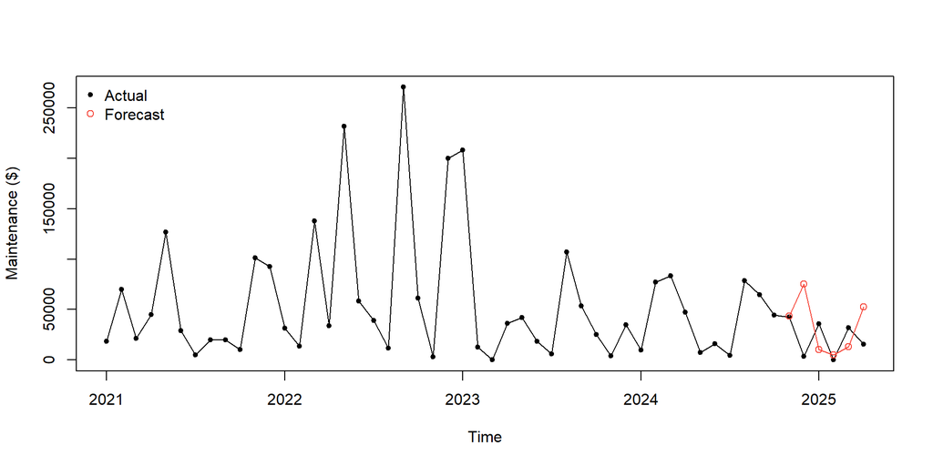

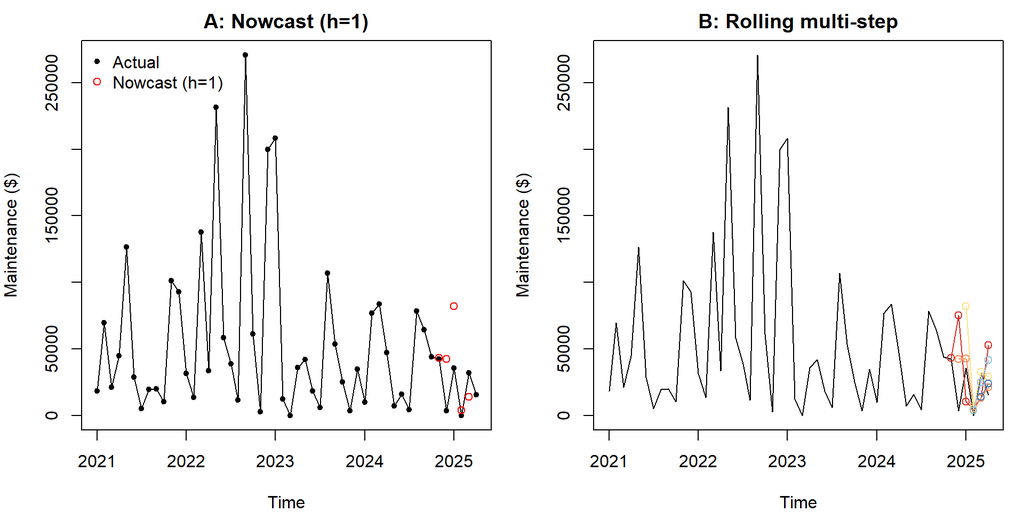

### Deployment (full re‑fit) and multi‑step forecasts

For horizons >1, you must provide an **exogenous path** for hours: - **Nowcast** (h=1): use known H_t and known lags. - **Short‑term forecast** (h>1): provide hour scenarios or forecast hours in a separate model and pass them via `dumvar`.

#### Flight Hours

```
         H_t       L1        L2
used      15 12.95665 0.2226325
expected   9 12.95665 0.2226325
```

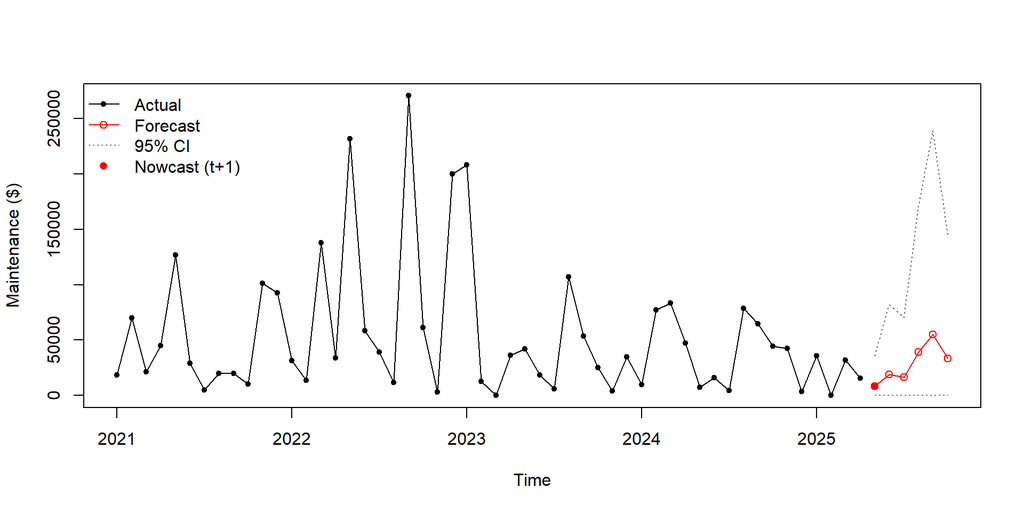

## Notes for decision-makers

- **When hours are trending:** We use the **change in hours** rather than the raw level. This makes short-term signals cleaner.
- **If we also need an hours forecast:** We run a simple hours forecast and **feed those results into the maintenance model** so both move together.
- **Method consistency:** Same settings as the baseline VAR. The **only change** is adding flight hours as an input.

# Small-cabin Business Jet

**Executive summary**

## Variable Analysis

### Maintenance

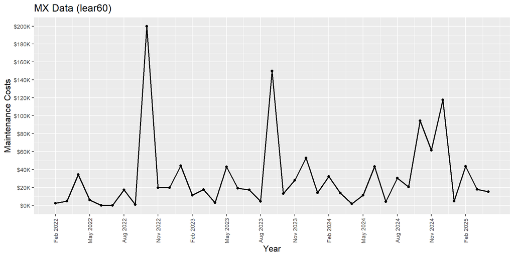

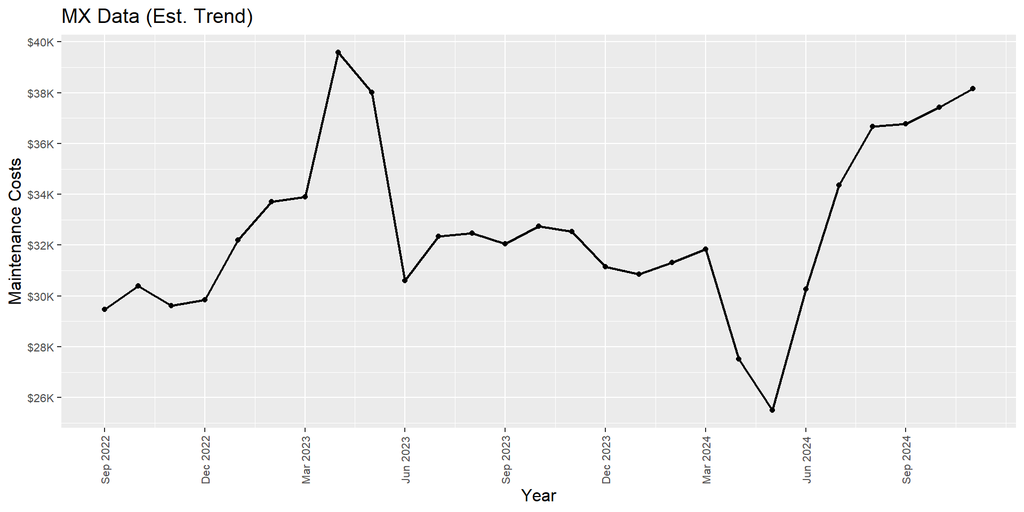

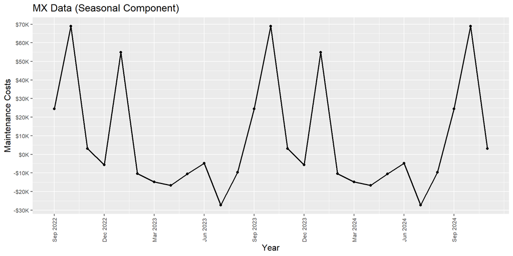

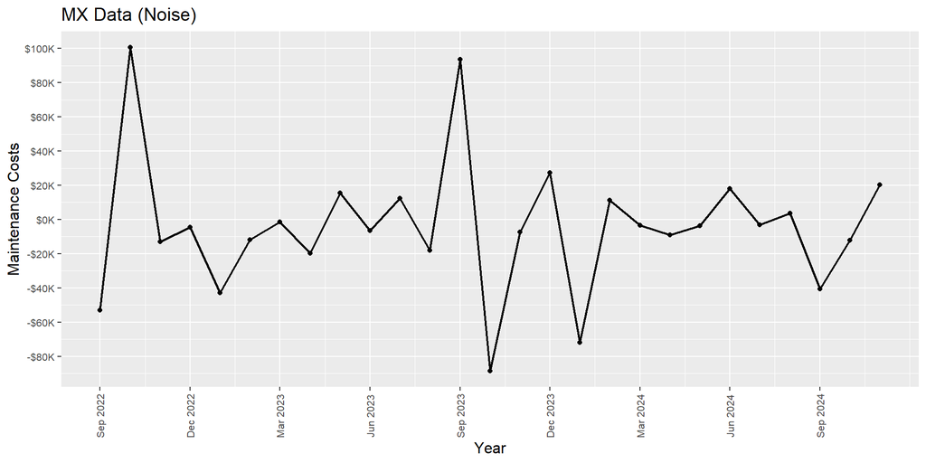

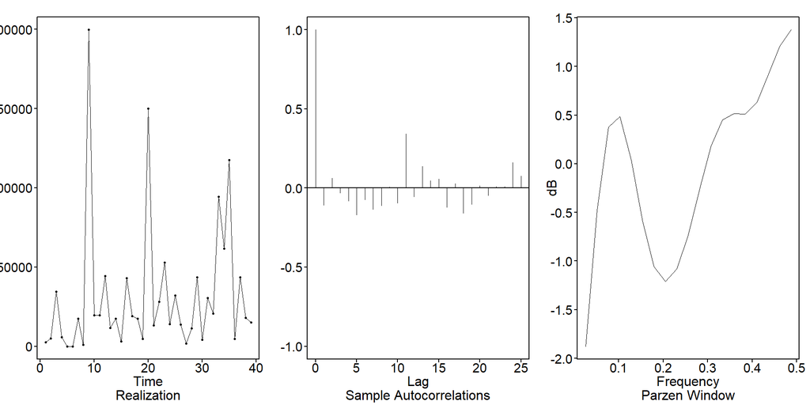

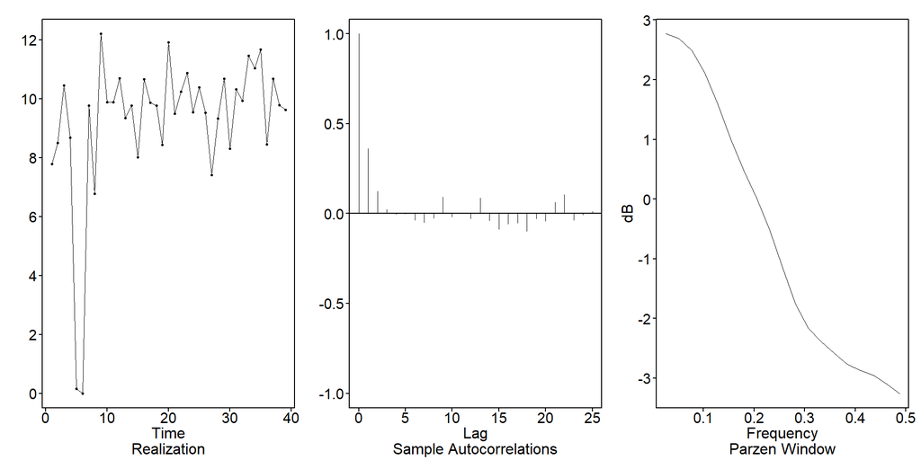

| Trend | Seasonality/Cycle | Near-term persistence |
| --- | --- | --- |
| flat (post-log) | none | no |

#### Interpretation of Sample Autocorrelations & Spectral Density

Monthly maintenance costs vary month-to-month within a narrow band after logging; large spikes are rare and isolated.

**Realization (Logged Data):**  
Maintenance costs fluctuate month-to-month within a relatively narrow and stable range after log transformation. This indicates that routine maintenance expenses are generally steady, apart from occasional large, isolated events.

**Takeaway:** past months add little predictive value; budget and staffing should not assume carryover effects.

**Spectral Density:**  
No consistent cyclicality or seasonal rhythms detected. The spectral analysis confirms that costs are driven primarily by irregular or isolated maintenance events rather than periodic patterns.

**Takeaway:** treat The small-cabin jet maintenance as event‑driven; plan for variance, not seasonality.

**Why Log Transformation?**  
The original data showed significant spikes due to a few extreme cost events. By applying a log transformation, we minimized the impact of these outliers, which improved our ability to see regular cost patterns and increased the reliability of our analysis

### Flight Hours

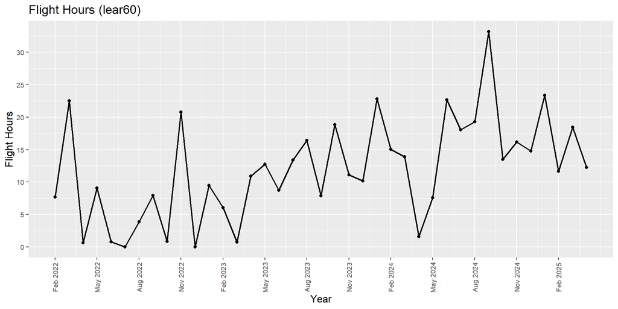

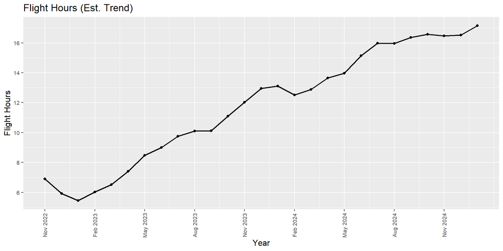

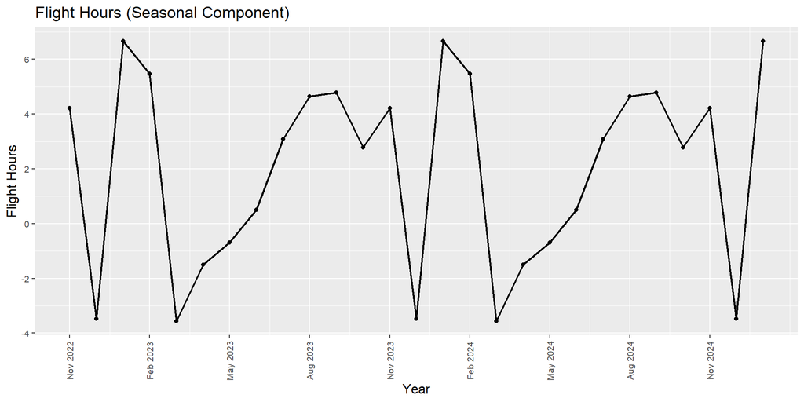

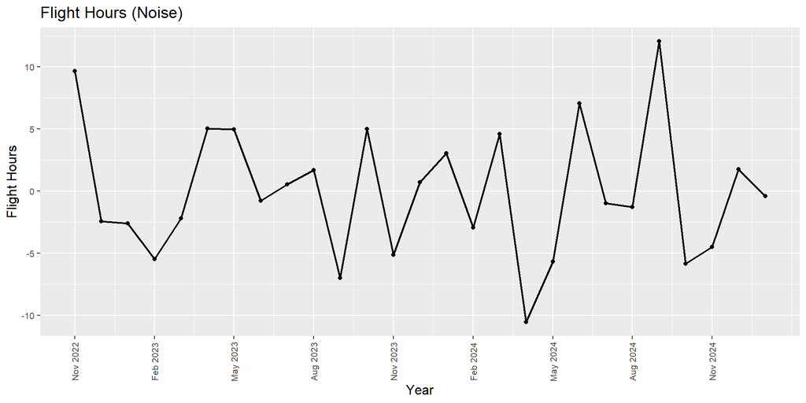

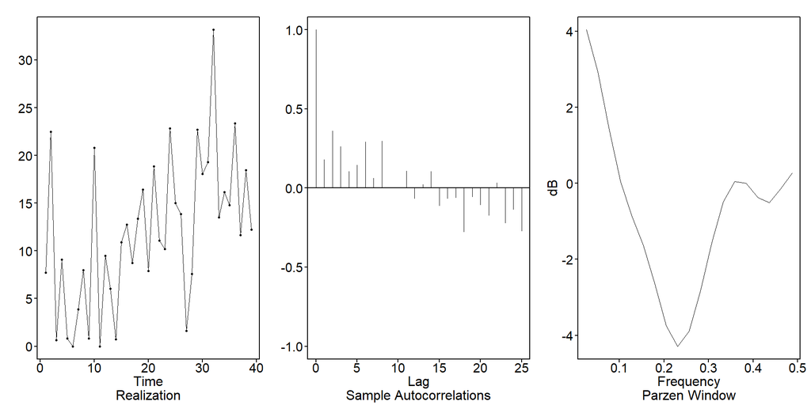

| Trend | Seasonality/Cycle | Near-term persistence |
| --- | --- | --- |
| ↑ | present (2–3 mo) | yes |